# Assignment_3

Dan Rodrigues

19/10/2021

## 1 - Random experiments, events and sample spaces

- Random Experiment = A procedure (real or imagined) which has a well-defined set of possible outcomes, and could (in principle) be repeated arbitrarily many times.
- Event = A set (or collection) or possible outcomes.
- Sample Space = The set of all possible outcomes of interest for a random experiment.

An example:

- My random experiment - I toss a fair coin, and want to see which side lands face up
- Possible outcomes - Heads (0), Tails (1)
- Events - The set of events is $\varepsilon=\{\emptyset, 0, 1, \{0,1\}\}$.
  - The empty-set is where neither outcome occurs (e.g. lands on side), which we deem impossible for the experiment.
  - The event $\{0\}$ occurs when the coin lands on heads.
  - The event $\{1\}$ occurs when the coin lands on tails.
  - The event $\{0, 1\}$ occurs when the coin lands on heads or tails (always occurs).
- Sample Space - The sample space is $\Omega = \{0,1\}$ and contains both desired outcomes (the coin landing heads, and the coin landing tails).

## 2 - Tidy data and iteration

### 2.1 - Missing data and iteration

The following function (provided) uses the “map_dbl” function, which is provided by the “purrr” library, which is part of the larger “tidyverse” library.

```r
library(tidyverse)
```

```r
impute_by_mean<-function(x){
  mu<-mean(x,na.rm=1) # first compute the mean of x
    impute_f<-function(z){ # coordinate-wise imputation
      if(is.na(z)){
        return(mu) # if z is na replace with mean
      }else{
        return(z) # otherwise leave in place
      }
    }
  return(map_dbl(x,impute_f)) # apply the map function to impute across vector
}
```

We now create a similar function to impute by median…

```r
impute_by_median <- function(x){
  mu<-median(x,na.rm=1) # first compute the median of x
    impute_f<-function(z){ # coordinate-wise imputation
      if(is.na(z)){
        return(mu) # if z is na replace with median
      }else{
        return(z) # otherwise leave in place
      }
    }
  return(map_dbl(x,impute_f)) # apply the map function to impute across vector
}

v<-c(1,2,NA,4)
impute_by_median(v)
```

```
## [1] 1 2 2 4
```

Now, generate a data frame, df_xy.

```r
x <- seq(from=0, to=10, by=0.1)
y <- 5 * x + 1
df_xy <- data.frame(x, y)

df_xy %>%
  mutate(z=map2_dbl(x, y, ~.x+.y)) %>%
  head(5)
```

```
##     x   y   z
## 1 0.0 1.0 1.0
## 2 0.1 1.5 1.6
## 3 0.2 2.0 2.2
## 4 0.3 2.5 2.8
## 5 0.4 3.0 3.4
```

Now, create a function to generate NA’s for indices divisible by 5.

```r
sometimes_missing <- function(index, value) {
  if(index %% 5 == 0) {
    return(NA)
  } else {
    return(value)
  }
}
```

Now, use the function to create df_xy_missing with missing data.

```r
df_xy_missing <- df_xy %>%
  mutate(y=map2_dbl(.x=row_number(), .y=y, sometimes_missing))

df_xy_missing %>%
  head(10)
```

```
##      x   y
## 1  0.0 1.0
## 2  0.1 1.5
## 3  0.2 2.0
## 4  0.3 2.5
## 5  0.4  NA
## 6  0.5 3.5
## 7  0.6 4.0
## 8  0.7 4.5
## 9  0.8 5.0
## 10 0.9  NA
```

Now, create a median-imputed version of df_xy_missing.

```r
df_xy_impute <- df_xy_missing %>%
  mutate(y = impute_by_median(y))

df_xy_impute %>%
  head(10)
```

```
##      x    y
## 1  0.0  1.0
## 2  0.1  1.5
## 3  0.2  2.0
## 4  0.3  2.5
## 5  0.4 26.0
## 6  0.5  3.5
## 7  0.6  4.0
## 8  0.7  4.5
## 9  0.8  5.0
## 10 0.9 26.0
```

Combining and plotting…

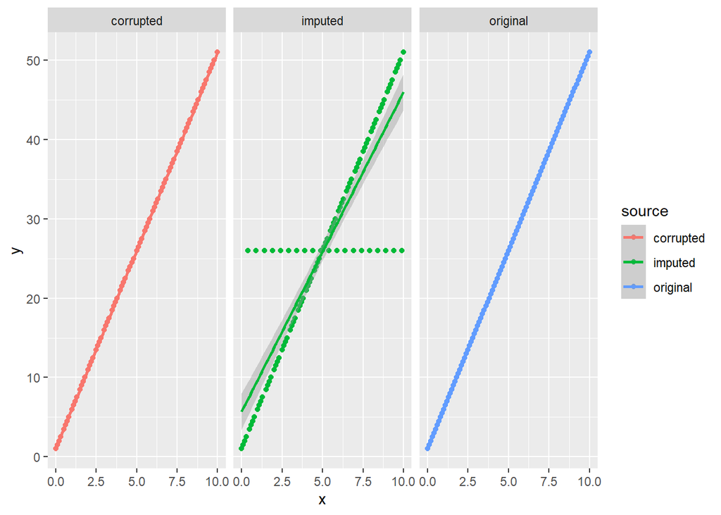

```r
df_xy <- df_xy %>%
  mutate(source="original")

df_xy_missing <- df_xy_missing %>%
  mutate(source="corrupted")

df_xy_impute <- df_xy_impute %>%
  mutate(source="imputed")

df_combined <- rbind(df_xy, df_xy_missing, df_xy_impute)

ggplot(df_combined, aes(x=x, y=y, color=source)) +
  geom_point() +
  facet_wrap(~source) +
  geom_smooth(method="lm")
```

### 2.2 - Tidying data with pivot functions

Here, we read in data from a spreadsheet, and apply some data wrangling operations to tidy the data. (Note: we are using an excel spreadsheet, so require the “readxl” library.)

```r
# Load the readxl library
library(readxl)

# Obtain file path for excel spreadsheet
folder_path <- "D:\\Documents\\GitHub\\EMATM0061_SCEM\\Assignment_3\\"
file_name <- "HockeyLeague.xlsx"
file_path <- paste(folder_path, file_name, sep="")

# Read of a sheet from an xl file
wins_data_frame <- read_excel(file_path, sheet="Wins")
```

```
## * `` -> ...1
```

```r
wins_data_frame %>%
  select(1:5) %>%
  head(3)
```

```
## # A tibble: 3 x 5
##   ...1   `1990`   `1991`   `1992`   `1993`
##   <chr>  <chr>    <chr>    <chr>    <chr>
## 1 Ducks  30 of 50 11 of 50 30 of 50 12 of 50
## 2 Eagles 24 of 50 12 of 50 37 of 50 14 of 50
## 3 Hawks  20 of 50 22 of 50 33 of 50 11 of 50
```

Note: this data is NOT tidy, as each cell contains composite / combined data, namely the number of wins AND total number of games per season, as opposed to being presented in different columns. A tidy variant would have one column displaying the all the wins, and another for the year - reading across, it would then be easy to extract how many wins a given team had in a particular year or season, which is likely one of the motivating questions behind the investigation / analysis.

Next, we apply some data wrangling operations to tidy up the data frame (creating “wins_tidy”).

```r
wins_tidy <- wins_data_frame %>%
  rename(Team = ...1) %>%
  pivot_longer(cols=!Team, names_to = "Year", values_to = "Data") %>%
  mutate(Year=as.integer(Year)) %>%
  separate(Data, into=c("Wins", "Total"), sep=" of ", convert=TRUE)

wins_tidy %>%
  head(5)
```

```
## # A tibble: 5 x 4
##   Team   Year  Wins Total
##   <chr> <int> <int> <int>
## 1 Ducks  1990    30    50
## 2 Ducks  1991    11    50
## 3 Ducks  1992    30    50
## 4 Ducks  1993    12    50
## 5 Ducks  1994    24    50
```

We do similar for the losses, and combine it all

```r
# Read, and tidy loss data
losses_tidy <- read_excel(file_path, sheet="Losses") %>%
  rename(Team = ...1) %>%
  pivot_longer(cols=!Team, names_to = "Year", values_to = "Data") %>%
  mutate(Year=as.integer(Year)) %>%
  separate(Data, into=c("Losses", "Total"), sep=" of ", convert=TRUE)
```

```
## * `` -> ...1
```

```r
losses_tidy %>%
  head(5)
```

```
## # A tibble: 5 x 4
##   Team   Year Losses Total
##   <chr> <int>  <int> <int>
## 1 Ducks  1990     20    50
## 2 Ducks  1991     37    50
## 3 Ducks  1992      1    50
## 4 Ducks  1993     30    50
## 5 Ducks  1994      7    50
```

```r
# Now combine data frames
hockey_df <- inner_join(wins_tidy, losses_tidy) %>%
  mutate(Draws=Total-Wins-Losses) %>%
  mutate(across(starts_with(c("Wins", "Losses", "Draws")), ~.x/Total, .names="{.col}_rt"))
hockey_df %>%
    head(5)
```

```
## # A tibble: 5 x 9
##   Team   Year  Wins Total Losses Draws Wins_rt Losses_rt Draws_rt
##   <chr> <int> <int> <int>  <int> <int>   <dbl>     <dbl>    <dbl>
## 1 Ducks  1990    30    50     20     0    0.6       0.4      0
## 2 Ducks  1991    11    50     37     2    0.22      0.74     0.04
## 3 Ducks  1992    30    50      1    19    0.6       0.02     0.38
## 4 Ducks  1993    12    50     30     8    0.24      0.6      0.16
## 5 Ducks  1994    24    50      7    19    0.48      0.14     0.38
```

Conclude by generating summary data frame…

```r
hockey_df %>%
  select(-Wins, -Draws, -Losses) %>%
  group_by(Team) %>%
  summarise(across(starts_with(c("Wins","Losses","Draws")), list(md=median, mn=mean),
  .names = "{substring(.col,1,1)}_{.fn}")) %>%
  arrange(desc(W_md))
```

```
## # A tibble: 8 x 7
##   Team         W_md  W_mn  L_md  L_mn  D_md  D_mn
##   <chr>       <dbl> <dbl> <dbl> <dbl> <dbl> <dbl>
## 1 Eagles      0.45  0.437 0.25  0.279 0.317 0.284
## 2 Penguins    0.45  0.457 0.3   0.310 0.133 0.232
## 3 Hawks       0.417 0.388 0.233 0.246 0.32  0.366
## 4 Ducks       0.383 0.362 0.34  0.333 0.25  0.305
## 5 Owls        0.32  0.333 0.3   0.33  0.383 0.337
## 6 Ostriches   0.3   0.309 0.4   0.395 0.267 0.296
## 7 Storks      0.3   0.284 0.22  0.283 0.48  0.433
## 8 Kingfishers 0.233 0.245 0.34  0.360 0.4   0.395
```

#### Note: Section 3 (Elementary Set Theory) and Section 4 (Introduction to Probability) are Omitted from this R Markdown document, given the omission of programmatic tasks in favour of mathematical problems. The included answer sheet provides typeset solutions to these questions.